# EX6

roi hezkiyahu

31 3 2022

# Q1

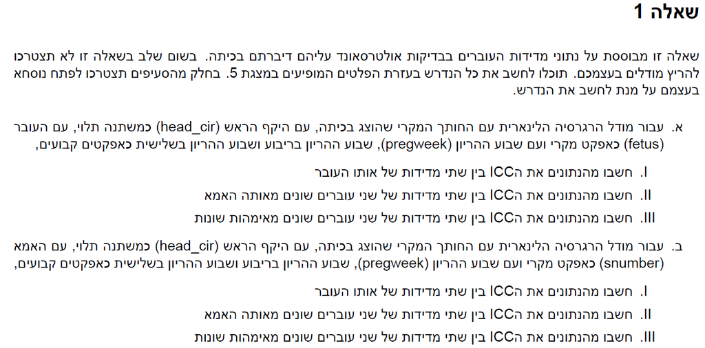

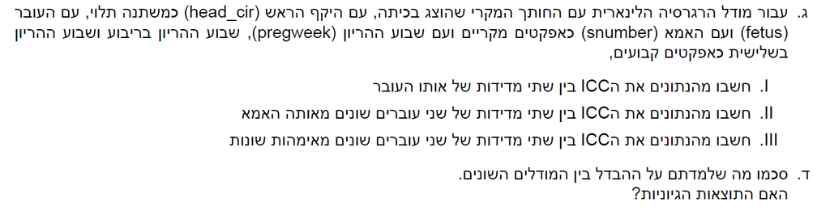

## a

$$1. \ \rho = \frac{\sigma_a^2}{\sigma_a^2 + \sigma_\varepsilon^2} = \frac{61.39}{61.39+44.33}=0.58
\\
2. \ \rho = cov(Y_{kij},Y_{ki'j'}) = 0 \quad(i \ne i')
\\
3. \ \rho = cov(Y_{kij},Y_{k'i'j'}) = 0 \quad(k \ne k')$$

## b

$$1. \ \rho = \frac{\sigma_a^2}{\sigma_a^2 + \sigma_\varepsilon^2} = \frac{44.69}{44.69+61.96}=0.419
\\
2. \ \rho = \frac{\sigma_a^2}{\sigma_a^2 + \sigma_\varepsilon^2} = \frac{44.69}{44.69+61.96}=0.419
\\
3. \ \rho = cov(Y_{kij},Y_{k'i'j'}) = 0 \quad(k \ne k')$$

## c

$$1. \ \rho = \frac{\sigma_a^2+sigma_b^2}{\sigma_a^2+sigma_b^2 + \sigma_\varepsilon^2} = \frac{37.59+23.54}{37.59+23.54+44.42}=0.579
\\
2. \ \rho = \frac{\sigma_b^2}{\sigma_a^2+sigma_b^2 + \sigma_\varepsilon^2} = \frac{23.54}{7.59+23.54+44.42}=0.223
\\
3. \ \rho = cov(Y_{kij},Y_{k'i'j'}) = 0 \quad(k \ne k')$$

## d

המודל הראשון מניח כי השונות היא עבור העוברים

המודל השני מניח כי השונות נובעות מהאמהות

והמודל השלישי מניח כי עבור כל עובר וכל אמא יש שונות אחרת

התוצאות לא כלכך מסתדרות שכן זה מוזר שהשונות עבור המודל הראשון גדולה מזאת של המודל השלישי.

# Q2

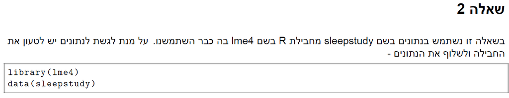

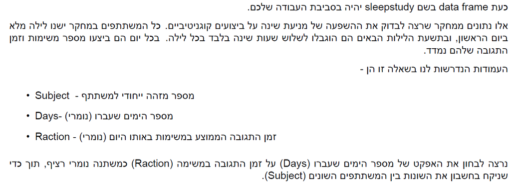

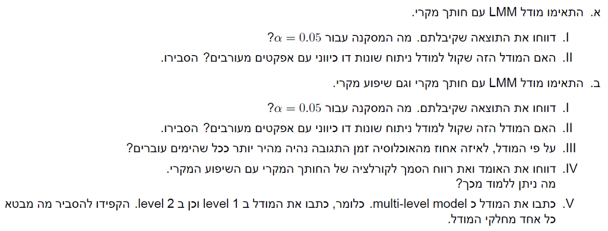

## a

```r
library(tidyverse)
library(lme4)
library(glue)
data("sleepstudy")
```

**1**

```r
model_1 <- lmer(Reaction ~ (1|Subject) + Days,data = sleepstudy)
confint(model_1)
```

```
## Computing profile confidence intervals ...
```

```
##                  2.5 %    97.5 %
## .sig01       26.007120  52.93598
## .sigma       27.813847  34.59105
## (Intercept) 231.992326 270.81788
## Days          8.886551  12.04802
```

אפס לא נמצא ברווח סמך ברמת סמך של 95% לכן ניתן לדחות את השערת ה0 עבור אלפא של 0.05

**2**

מודל זה שקול למודל ניתוח שונות די כיווני עם אפקטים מעורבים

## b

**1**

```r
model_2 <- lmer(Reaction ~ (1+Days|Subject) + Days,data = sleepstudy)
summary(model_2)
```

```
## Linear mixed model fit by REML ['lmerMod']
## Formula: Reaction ~ (1 + Days | Subject) + Days
##    Data: sleepstudy
##
## REML criterion at convergence: 1743.6
##
## Scaled residuals:
##     Min      1Q  Median      3Q     Max
## -3.9536 -0.4634  0.0231  0.4634  5.1793
##
## Random effects:
##  Groups   Name        Variance Std.Dev. Corr
##  Subject  (Intercept) 612.10   24.741
##           Days         35.07    5.922   0.07
##  Residual             654.94   25.592
## Number of obs: 180, groups:  Subject, 18
##
## Fixed effects:
##             Estimate Std. Error t value
## (Intercept)  251.405      6.825  36.838
## Days          10.467      1.546   6.771
##
## Correlation of Fixed Effects:
##      (Intr)
## Days -0.138
```

```r
confint(model_2)
```

```
## Computing profile confidence intervals ...
```

```
##                   2.5 %      97.5 %
## .sig01       14.3814764  37.7159954
## .sig02       -0.4815008   0.6849862
## .sig03        3.8011641   8.7533807
## .sigma       22.8982669  28.8579965
## (Intercept) 237.6806955 265.1295147
## Days          7.3586533  13.5759188
```

**2**

המודלים אינם שקולים שכן מודל זה מתאים שיפוע אחר עבור כל נבדק ואילו מודל ניתוח שונות דו כיווני עם אפקטים מעורבים לא עושה זאת

**3**

```r
glue("for {round(1- pnorm(0,10.467,5.922),3)*100} %")
```

```
## for 96.1 %
```

**4**

מהפלט של סעיף 1 ניתן לראות כי האומדן הינו 0.07

וכן רווח הסמך הינו:

(-0.4815,0.6849)

אנו לומדים מזה כי אין מובהקות לכך שיש קורצליה בין החותך המקרי לשיפוע המקרי

**5**

$$\textrm{Level 1: }
\\
Reaction_{ij} = \beta_{0i} + \beta_{1i}Days_{ij} + \varepsilon_{ij}
\\
\textrm{Where:}
\\
Rreaction_{ij} - \textrm{average reaction time of subject i after day j}
\\
Days_{ij} - \textrm{Day j for subject i}
\\
\beta_{0i} - \textrm{intercept of subject i}
\\
\beta_{1i} - \textrm{slope of subject i}
\\
\varepsilon_{ij} - \textrm{resitual of subject i at day j} \sim N(0,\sigma_\varepsilon^2)$$

$$\textrm{Level 2: }
\\
\beta_{0i} = \beta_0 + b_{0i}
\\
\beta_{1i} = \beta_1 + b_{1i}
\\
\textrm{Where:}
\\
\beta_0 - \textrm{general intercept}
\\
b_{0i} - \textrm{addition to intercept for subject i} \sim N(0,\sigma_{0b}^2)
\\
\beta_1 - \textrm{general slope}
\\
b_{1i} - \textrm{addition to slope for subject i} \sim N(0,\sigma_{1b}^2)$$